# CSSS/STAT 564 Lab Sessions #1

## Discrete distribution: Poisson

The Poisson distribution is useful for modeling count data; it’s a discrete distribution that only takes on integer values that are nonnegative. We recall that a Poisson distribution with mean parameter $\lambda$ has the following probability mass function:

$$\begin{align*}
\operatorname{Pr}(X=k)=\frac{\lambda^{k} e^{-\lambda}}{k !}
\end{align*}$$

To calculate this in RStudio, we can use `dpois` to analytically calculate the density for a Poisson distribution with $\lambda$=5. (We stop at an arbitrary large value of $x$.)

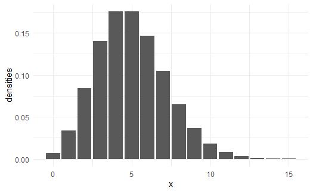

```r
xs <- 0:15 # stop at x=15
densities <- dpois(x = xs, lambda = 5) # calculates the poisson likelihood for x from 0 to 15 with mean parameter 5
df <- tibble(x = xs, densities = densities) # create a dataframe with the xs and the densities
ggplot(df, aes(x = x, y = densities)) + geom_col() # plot the densities as columns
```

Then, if we draw samples from the same distribution, we should get something close to the theoretical densities (i.e. the shape of the histogram of counts should be similar to the shape of the density function).

To do this, we use the function `rpois` to generate i.i.d samples from the Poisson distribution $\text{Poisson}(\lambda = 5)$.

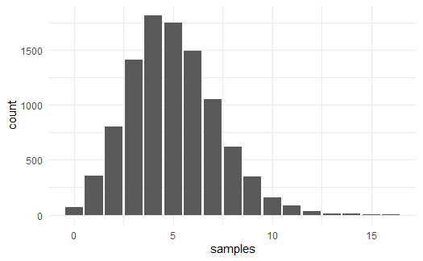

```r
poisson_samples <- rpois(n = nsims, lambda = 5)
# first, plot counts
tibble(samples = poisson_samples) %>%
  ggplot(aes(x = samples)) +
  geom_bar()
```

We can also overlay these two together:

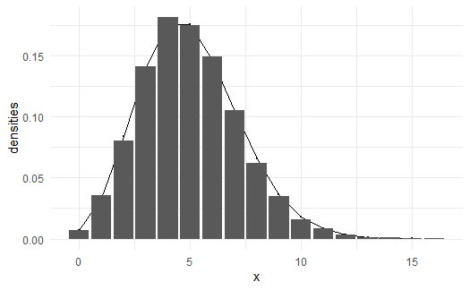

```r
# plot the density function/mass function of the Poisson density against the bar plot of empirical rates based on samples from the distribution
# tally the samples by their values and calculate the rate for each value
df2 <- tibble(samples = poisson_samples) %>%
  count(samples) %>%
  mutate(frac = n/nsims)
# overlay the two graphs
df %>% ggplot(aes(x = x, y = densities)) +
  geom_point(size = .5) +
  geom_line() +
  geom_col(data = df2, aes(x = samples, y = frac))
```

## Continuous distribution: Gamma

The gamma distribution is a continuous probability distribution. We can plot an approximation of the shape from the true densities using a grid of values. A gamma distribution with shape parameter $\alpha$ and rate parameter $\beta$ has the following probability density function (beware of the specification of the parameters! If we use the scale parameter instead of the rate parameter, it is the inverse of $\beta$):

$$\begin{align*}
f(x)=\frac{\beta^{\alpha}}{\Gamma(\alpha)} x^{\alpha-1} e^{-\beta x}
\end{align*}$$

We’ll use $\text{Gamma}(2,0.1)$ —a shape parameter of 2, and a rate (or inverse scale) parameter of 0.1. Try changing these values and see how the distribution changes.

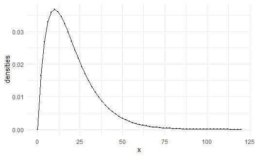

```r
# analytic densities: construct a set of grid values from 0 to 120
xs <- seq(0, 120, by = 2)
# be careful of the parameter: rate or scale?
gamma_densities <- dgamma(x = xs, shape = 2, rate = 0.1)
# plot the density values on a line
p1 <- tibble(x = xs, densities = gamma_densities) %>%
  ggplot(aes(x = x, y = densities)) +
  geom_point(size = .5) +
  geom_line()
p1
```

Since this is a continuous distribution, we’ll use a kernel density (rather than a histogram) to plot the samples.

```r
# densities from samples
gamma_samples <- rgamma(n = nsims, shape = 2, rate = 0.1)
df.2 <- tibble(samples = gamma_samples)
p2 <- data_frame(samples = gamma_samples) %>%
  ggplot(aes(x = samples)) +
  geom_density()
```

```
`data_frame()` was deprecated in tibble 1.1.0.
Please use `tibble()` instead.
```

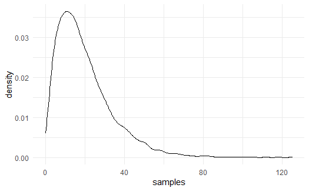

```r
p2
```

If you know the theoretical distribution, another way to compare the samples to it is with a quantile-quantile plot:

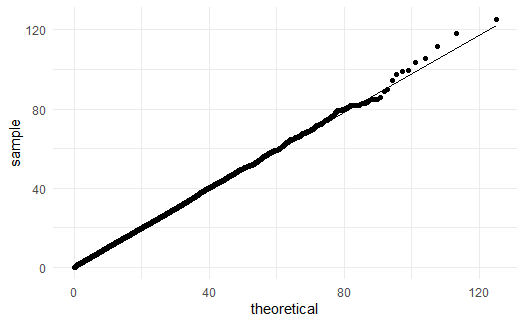

```r
tibble(samples = gamma_samples) %>%
  ggplot(aes(sample = samples)) +
  geom_qq(distribution = qgamma,
          dparams = list(shape = 2, rate = 0.1)) +  # generate points with coordinates as theoretical and empirical quantiles
  geom_qq_line(distribution = qgamma,
               dparams = list(shape = 2, rate = 0.1)) # generate the reference line
```

Key thing to notice here: the approximation is less good in the long tail.

## Distributional summaries

### single-valued summaries: mean, median and mode

There are multiple ways to summarize the central tendency of a distribution with a single value, including the mean, median, and mode (the value with the highest probability density). For some distributions (e.g. the normal distribution), these values are the same...but that’s not always true.

If you’re giving a point estimate for a parameter, one of these values would be what you’d report.

We can calculate those values from the Poisson samples:

```r
# strangely, R doesn't have a built-in function for calculating mode, so we need to code our own:
mode <- function(x) {
  return(as.numeric(tibble(samples = x) %>%
  count(samples) %>%
  filter(n == max(n)))[1])
}
mean(poisson_samples)
```

```
[1] 4.9746
```

```r
median(poisson_samples)
```

```
[1] 5
```

```r
mode(poisson_samples)
```

```
[1] 4
```

```r
# or use Mode() in package LaplacesDemon
LaplacesDemon::Mode(poisson_samples)
```

```
[1] 4
```

Try the same for the gamma samples!

### Intervals

We can also use intervals to summarize distributions. In this course we will place a large focus on **credible intervals**, which is constructed based on the (in our case, usually posterior) distribution of a given parameter. There are two common intervals used to summarize distributions: percentiles and HDIs (highest density intervals).

### Comparing percentile interval and HDI

```r
summary(gamma_samples)
```

```
   Min. 1st Qu.  Median    Mean
  0.110   9.591  16.603  19.838
3rd Qu.    Max.
 26.492 125.207
```

```r
quantile(gamma_samples, probs = c(.25, .75))
```

```
      25%       75%
 9.591237 26.491549
```

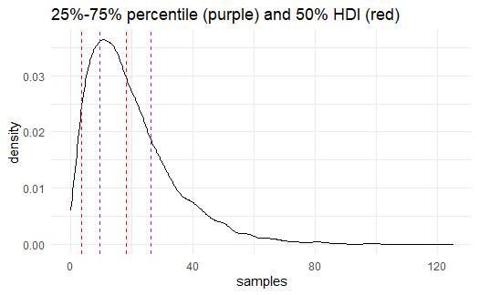

```r
hdi <- hdi(gamma_samples, credMass=0.5)
df <- data_frame(samples = gamma_samples)
p.interval <- ggplot(df, aes(x = samples)) + geom_density()
p.interval +
  geom_vline(xintercept = quantile(gamma_samples, probs = c(.25, .75)),
             color = "purple", linetype = "dashed")+
  geom_vline(xintercept = c(hdi[1], hdi[2]),
             color = "red", linetype = "dashed") +
  labs(title = "25%-75% percentile (purple) and 50% HDI (red)")
```

### Comparing mean, median and mode

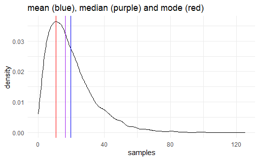

```r
p.interval + geom_vline(xintercept = mean(gamma_samples), color = "blue") +
  geom_vline(xintercept = median(gamma_samples), color = "purple") +
  geom_vline(xintercept = LaplacesDemon::Mode(gamma_samples), color = "red") +
  labs(title = "mean (blue), median (purple) and mode (red)")
```

What should you use? It depends! The mean is commonly used in Bayesian statistics, though rstan and bayesplot use the median and percentiles by default. The mode is less common, but it has a nice correspondence to the maximum likelihood estimate. In a Bayesian context, this is called maximum a posteriori estimation.

## Monte Carlo Simulation

Approximating probability masses and densities through sampling is called Monte Carlo simulation. For continuous distributions, we’re approximating an integral. You can do this for arbitrary parts of the distribution:

$$X \sim N(0,1), P(-1 \leq X \leq 1) \approx ?$$

```r
normal_samples <- rnorm(nsims, mean = 0, sd = 1)
# how much probability is between -1 and +1 sd in a normal distribution?
sum(normal_samples >= -1 & normal_samples <= 1) / nsims
```

```
[1] 0.6793
```

```r
pnorm(1) - pnorm(-1)
```

```
[1] 0.6826895
```

Try changing `nsims` and the lower and upper bounds to see how the approximation improves.

# Poll: Slides or markdown??